# Temporal structure and cross-situational word learning

Analysis walkthrough for the paper “The temporal structure of naming events differentially affects children’s and adults’ cross-situational word learning” (Benitez, Zettersten & Wojcik, 2019).

See CrossSitRep_codebook for information about individual columns.

## Reading in data and preliminary processing

```r
#### read in complete data set ####
all_data <- read.csv("CrossSitRep_allData.csv")

#analyze just test trials
all_data <- filter(all_data,trial_type=="test")

##### KIDS ####
kids <- filter(all_data,group=="kids")

####Check for Side Bias####
bias <-  kids %>%
  group_by(id) %>%
  summarize(left=sum(length(which(response_location=='left'))))
bias_list <- bias %>%
  filter(left>6 | bias$left<2) %>%
  select(id)

#take out biased kids
kids <- kids %>%
  filter(!(id %in% bias_list$id))

#add age group info
kids$age <- as.numeric(kids$age)
kids$ageGroup <-  ifelse(kids$age<5,'four',
                         ifelse(kids$age>=5 & kids$age<6,'five',
                                ifelse(kids$age>=6 & kids$age<7,'six','seven')))
```

## Demographics

### Children

#### Age, Gender, Native Language

```r
####summarize by subject####
kids_subj <-  kids %>%
  group_by(id, group,age,ageGroup, gender,race, ole, parentEd,order, set, condition, expLabels) %>%
  summarize(accuracy = mean(as.numeric(as.character(accuracy))))

####summarize demographics####
kids_demographics <-  kids_subj %>%
  group_by(group,condition) %>%
  summarize(N=n(),
            mean_age = mean(age),
            sd_age = sd(age),
            min_age = min(age),
            max_age = max(age),
            count_female = length(which(gender=='F')),
            language_other_than_english = length(which(ole=='yes')))
kable(kids_demographics)
```

| group | condition | N | mean_age | sd_age | min_age | max_age | count_female | language_other_than_english |
| --- | --- | --- | --- | --- | --- | --- | --- | --- |
| kids | Interleaved | 40 | 5.944521 | 1.128706 | 4.065753 | 7.912329 | 24 | 12 |
| kids | Massed | 40 | 5.793219 | 1.003854 | 4.197260 | 7.928767 | 32 | 8 |
| kids | Unstructured | 30 | 5.728005 | 1.005394 | 4.000000 | 7.790000 | 18 | 4 |

#### Ethnicity

```r
kids_race <- kids_subj %>%
  group_by(group, condition, race) %>%
  summarize(count=n())
kable(kids_race)
```

| group | condition | race | count |
| --- | --- | --- | --- |
| kids | Interleaved | Asian | 3 |
| kids | Interleaved | Black or African American | 2 |
| kids | Interleaved | Hispanic or Latino | 5 |
| kids | Interleaved | Multi | 1 |
| kids | Interleaved | White | 29 |
| kids | Massed | Asian | 2 |
| kids | Massed | Black or African American | 3 |
| kids | Massed | Hispanic or Latino | 4 |
| kids | Massed | Multi | 9 |
| kids | Massed | N/A | 1 |
| kids | Massed | White | 21 |
| kids | Unstructured | Asian | 1 |
| kids | Unstructured | Hispanic or Latino | 1 |
| kids | Unstructured | Multi | 3 |
| kids | Unstructured | White | 24 |
| kids | Unstructured | NA | 1 |

#### Parental Education

```r
kids_edu <- kids_subj %>%
  group_by(group, condition, parentEd) %>%
  summarize(count=n())
kable(kids_edu)
```

| group | condition | parentEd | count |
| --- | --- | --- | --- |
| kids | Interleaved | associates | 4 |
| kids | Interleaved | bachelors | 11 |
| kids | Interleaved | highschool | 3 |
| kids | Interleaved | masters | 14 |
| kids | Interleaved | phd | 3 |
| kids | Interleaved | somecollege | 4 |
| kids | Interleaved | somehigh | 1 |
| kids | Massed | associates | 7 |
| kids | Massed | bachelors | 14 |
| kids | Massed | highschool | 4 |
| kids | Massed | masters | 6 |
| kids | Massed | phd | 3 |
| kids | Massed | somecollege | 5 |
| kids | Massed | somehigh | 1 |
| kids | Unstructured | associates | 2 |
| kids | Unstructured | bachelors | 11 |
| kids | Unstructured | masters | 5 |
| kids | Unstructured | phd | 4 |
| kids | Unstructured | somecollege | 5 |
| kids | Unstructured | somehigh | 1 |
| kids | Unstructured | NA | 2 |

### Adults

#### Age, Gender, Native Language

```r
####ADULTS####
adults <- filter(all_data,group=="adults")

####summarize by subject####
adults_subj <-  adults %>%
  group_by(id, group,age,gender,ole,engNative,order, set, condition, expLabels) %>%
  summarize(accuracy = mean(as.numeric(as.character(accuracy))))

####summarize demographics####
adults_demographics <-  adults_subj %>%
  group_by(group,condition) %>%
  summarize(N=n(),mean_age = mean(age), sd_age = sd(age), min_age = min(age), max_age = max(age),
            count_female = length(which(gender=='F')), count_ole = length(which(ole=='yes')),
            count_nonNative = length(which(engNative=='No')))

kable(adults_demographics)
```

| group | condition | N | mean_age | sd_age | min_age | max_age | count_female | count_ole | count_nonNative |
| --- | --- | --- | --- | --- | --- | --- | --- | --- | --- |
| adults | Interleaved | 30 | 18.83333 | 0.7914776 | 18 | 21 | 15 | 4 | 0 |
| adults | Massed | 30 | 19.46667 | 1.5477087 | 18 | 25 | 6 | 5 | 1 |
| adults | Unstructured | 30 | 18.86667 | 1.0416609 | 18 | 22 | 14 | 5 | 0 |

## Plotting Test Accuracy

### Children

#### Plotting Test Accuracy by Condition

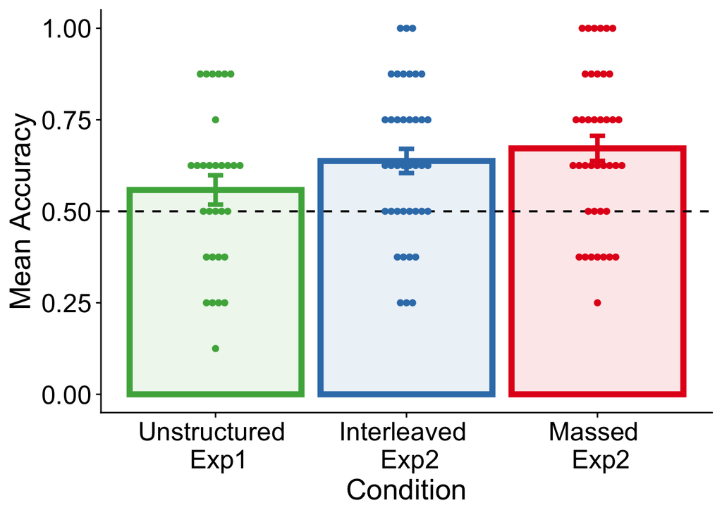

```r
####summarize accuracy####
kids_summarized <-  kids_subj %>%
  group_by(group,condition) %>%
  summarize(mean_accuracy = mean(accuracy), N=n(), SD = sd(accuracy), SE = se(accuracy))
kids_summarized$condition = factor(kids_summarized$condition, levels = c("Unstructured","Interleaved","Massed"))

####plot kids data####
p1 <- ggplot(kids_summarized,aes(condition,mean_accuracy, color=condition,fill=condition))+
  geom_bar(stat="identity",alpha=0.1,size=2) +
  geom_hline(yintercept = 0.50, linetype = 'dashed', size = 0.70)+
  geom_dotplot(data=kids_subj,aes(y=accuracy),binaxis="y",stackdir="center",dotsize=0.5) +
  scale_y_continuous(name = "Mean Accuracy",limits=c(0,1)) +
  scale_x_discrete(name="Condition",
                   limits=c("Unstructured","Interleaved","Massed"),
                   labels=c("Unstructured \n Exp1","Interleaved \n Exp2", "Massed \n Exp2")) +
  geom_errorbar(size=1.5,width=.08, aes(ymin=mean_accuracy-SE,ymax=mean_accuracy+SE))+
  scale_fill_brewer(name="Condition",
                    limits=c("Unstructured","Interleaved","Massed"),
                    labels=c("Unstructured \n Exp1","Interleaved \n Exp2", "Massed \n Exp2"),
                    palette="Set1",direction=-1)+
  scale_color_brewer(name="Condition",
                     limits=c("Unstructured","Interleaved","Massed"),
                     labels=c("Unstructured \n Exp1","Interleaved \n Exp2", "Massed \n Exp2"),
                     palette="Set1",direction=-1)+
  theme(legend.position="none",
        axis.text  = element_text(size=18),
        axis.title = element_text(size=20),
        plot.title = element_text(size=24))
p1
```

#### Relationship between accuracy and age

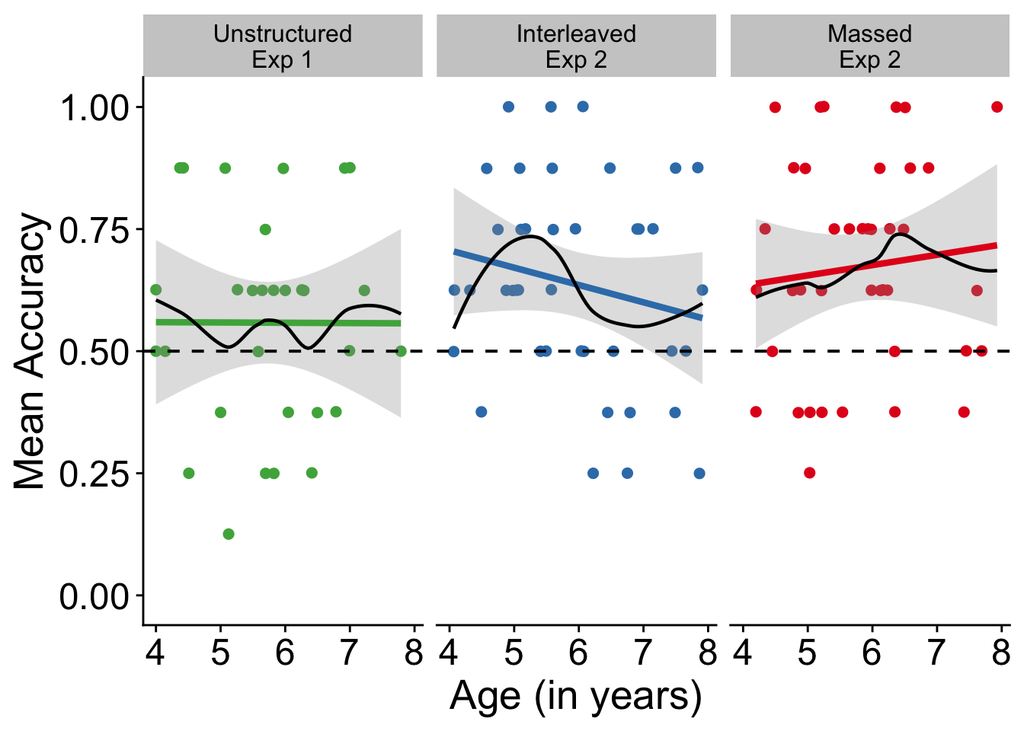

```r
#age-related analysis
kids_subj$conditionName <- factor(kids_subj$condition,levels=c("Unstructured","Interleaved","Massed"),,labels=c("Unstructured\nExp 1","Interleaved\nExp 2","Massed\nExp 2"))
ggplot(kids_subj,aes(age, accuracy,group=conditionName, color=conditionName))+
  geom_jitter(width=0.001,height=0.001,size=2)+
  geom_smooth(method="lm",size=1.5,alpha=0.3)+
  geom_smooth(aes(group=NULL),color="black",se=F,size=0.8)+
  scale_color_brewer(name="Condition",
                     palette="Set1",direction=-1)+
  scale_y_continuous(breaks=c(0,0.25,0.5,0.75,1),limits=c(-0.01,1.01))+
  theme(legend.position="none",
        axis.text  = element_text(size=18),
        axis.title = element_text(size=20),
        plot.title = element_text(size=24))+
  geom_hline(yintercept = 0.50, linetype = 'dashed', size = 0.70)+
  facet_wrap(~conditionName)+
  xlab("Age (in years)")+
  ylab("Mean Accuracy")
```

### Adults

#### Plotting Test Accuracy by Condition

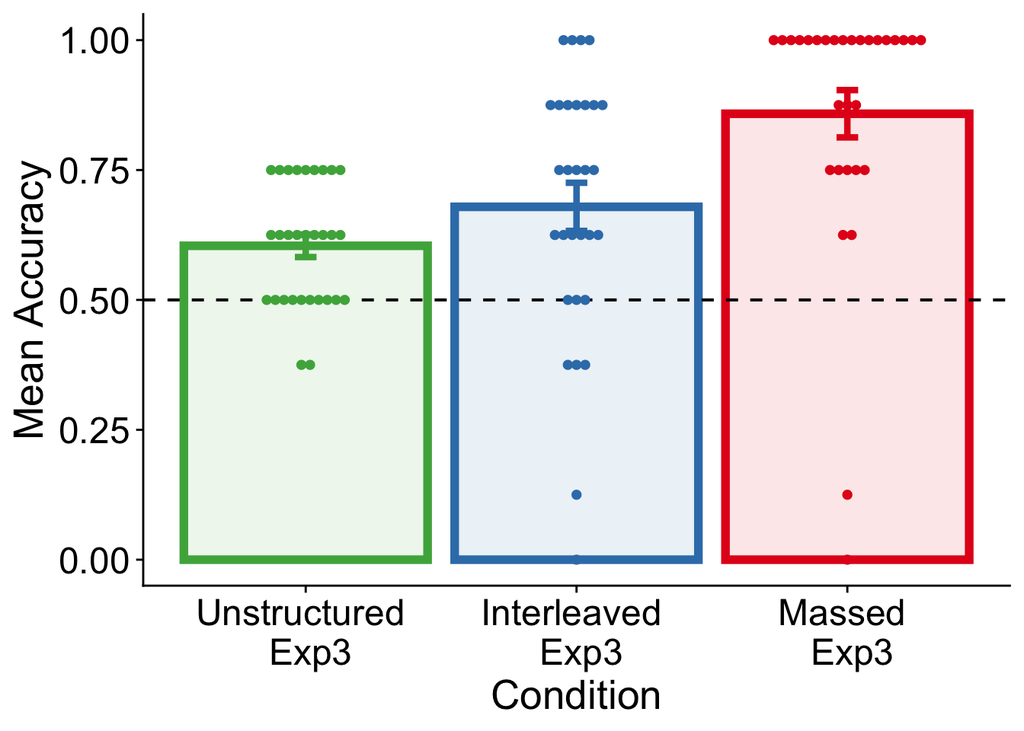

```r
####summarize accuracy####
adults_summarized <-  adults_subj %>%
  group_by(group,condition) %>%
  summarize(mean_accuracy = mean(accuracy), N=n(), SD = sd(accuracy), SE = se(accuracy))
adults_summarized$condition = factor(adults_summarized$condition, levels = c("Unstructured","Interleaved","Massed"))

####plot adult data####
p2 <- ggplot(adults_summarized,aes(condition,mean_accuracy, color=condition,fill=condition))+
  geom_bar(stat="identity",alpha=0.1,size=2) +
  geom_hline(yintercept = 0.50, linetype = 'dashed', size = 0.70)+
  geom_dotplot(data=adults_subj,aes(y=accuracy),binaxis="y",stackdir="center",dotsize=0.5) +
  scale_y_continuous(name = "Mean Accuracy",limits=c(0,1)) +
  scale_x_discrete(name="Condition",
                   limits=c("Unstructured","Interleaved","Massed"),
                   labels=c("Unstructured \n Exp3","Interleaved \n Exp3", "Massed \n Exp3")) +
  geom_errorbar(size=1.5,width=.08, aes(ymin=mean_accuracy-SE,ymax=mean_accuracy+SE))+
  scale_fill_brewer(name="Condition",
                    limits=c("Unstructured","Interleaved","Massed"),
                    labels=c("Unstructured \n Exp3","Interleaved \n Exp3", "Massed \n Exp3"),
                    palette="Set1",direction=-1)+
  scale_color_brewer(name="Condition",
                     limits=c("Unstructured","Interleaved","Massed"),
                     labels=c("Unstructured \n Exp3","Interleaved \n Exp3", "Massed \n Exp3"),
                     palette="Set1",direction=-1)+
  theme(legend.position="none",
        axis.text  = element_text(size=18),
        axis.title = element_text(size=20),
        plot.title = element_text(size=24))
p2
```

## Results

### Experiment 1

#### Relationship between age and accuracy

We fit a linear model predicting participant accuracy from age. Below is a summary of the model output.

```r
m <- lm(accuracy~age, data=subset(kids_subj, condition=='Unstructured'))
summary(m)
```

```
##
## Call:
## lm(formula = accuracy ~ age, data = subset(kids_subj, condition ==
##     "Unstructured"))
##
## Residuals:
##      Min       1Q   Median       3Q      Max
## -0.43370 -0.18282  0.06600  0.06743  0.31744
##
## Coefficients:
##               Estimate Std. Error t value Pr(>|t|)
## (Intercept)  0.5618000  0.2398836   2.342   0.0265 *
## age         -0.0006052  0.0412691  -0.015   0.9884
## ---
## Signif. codes:  0 '***' 0.001 '**' 0.01 '*' 0.05 '.' 0.1 ' ' 1
##
## Residual standard error: 0.2234 on 28 degrees of freedom
## Multiple R-squared:  7.681e-06,  Adjusted R-squared:  -0.03571
## F-statistic: 0.0002151 on 1 and 28 DF,  p-value: 0.9884
```

#### Overall accuracy

##### Main logistic mixed-effects model

Below is a summary of the logistic mixed-effects model testing children’s accuracy against chance.

```r
#test for difference from chance (0.5)
m <- glmer(accuracy ~ 1 + (1|id)+(1|correct),
            data=subset(kids, condition=='Unstructured'), family=binomial)
summary(m)
```

```
## Generalized linear mixed model fit by maximum likelihood (Laplace
##   Approximation) [glmerMod]
##  Family: binomial  ( logit )
## Formula: accuracy ~ 1 + (1 | id) + (1 | correct)
##    Data: subset(kids, condition == "Unstructured")
##
##      AIC      BIC   logLik deviance df.resid
##    331.0    341.4   -162.5    325.0      237
##
## Scaled residuals:
##     Min      1Q  Median      3Q     Max
## -1.5323 -1.0090  0.6526  0.8066  1.3076
##
## Random effects:
##  Groups  Name        Variance Std.Dev.
##  id      (Intercept) 0.3457   0.5880
##  correct (Intercept) 0.1000   0.3162
## Number of obs: 240, groups:  id, 30; correct, 8
##
## Fixed effects:
##             Estimate Std. Error z value Pr(>|z|)
## (Intercept)   0.2591     0.2070   1.252    0.211
```

Below are 95% Wald confidence interval for model coefficients.

```r
confint(m, method="Wald")
```

```
##                  2.5 %    97.5 %
## .sig01              NA        NA
## .sig02              NA        NA
## (Intercept) -0.1466413 0.6649189
```

Significance levels are assessed using a type III Wald chi-squared test.

```r
Anova(m,type="III")
```

```
## Analysis of Deviance Table (Type III Wald chisquare tests)
##
## Response: accuracy
##              Chisq Df Pr(>Chisq)
## (Intercept) 1.5667  1     0.2107
```

##### One-sample t-test against chance

```r
t.test(filter(kids_subj, condition=='Unstructured')$accuracy, mu=0.5)
```

```
##
##  One Sample t-test
##
## data:  filter(kids_subj, condition == "Unstructured")$accuracy
## t = 1.4552, df = 29, p-value = 0.1563
## alternative hypothesis: true mean is not equal to 0.5
## 95 percent confidence interval:
##  0.4763505 0.6403162
## sample estimates:
## mean of x
## 0.5583333
```

### Experiment 2

#### Relationship between age and accuracy

##### Test for age differences across conditions

First, we tested whether there were any differences in age across condition and experiments.

There were no differences in age across conditon:

```r
m <- lm(age~condition, data=subset(kids_subj, condition!='Unstructured'))
summary(m)
```

```
##
## Call:
## lm(formula = age ~ condition, data = subset(kids_subj, condition !=
##     "Unstructured"))
##
## Residuals:
##      Min       1Q   Median       3Q      Max
## -1.87877 -0.86438  0.02839  0.69514  2.13555
##
## Coefficients:
##                 Estimate Std. Error t value Pr(>|t|)
## (Intercept)       5.9445     0.1689  35.199   <2e-16 ***
## conditionMassed  -0.1513     0.2388  -0.633    0.528
## ---
## Signif. codes:  0 '***' 0.001 '**' 0.01 '*' 0.05 '.' 0.1 ' ' 1
##
## Residual standard error: 1.068 on 78 degrees of freedom
## Multiple R-squared:  0.005119,   Adjusted R-squared:  -0.007636
## F-statistic: 0.4013 on 1 and 78 DF,  p-value: 0.5283
```

There were no differences in age across Experiment 1 and 2.

```r
m <- lm(age~expLabels, data=kids_subj)
summary(m)
```

```
##
## Call:
## lm(formula = age ~ expLabels, data = kids_subj)
##
## Residuals:
##      Min       1Q   Median       3Q      Max
## -1.80312 -0.82161  0.02017  0.65853  2.06200
##
## Coefficients:
##               Estimate Std. Error t value Pr(>|t|)
## (Intercept)     5.7280     0.1915  29.919   <2e-16 ***
## expLabelsExp2   0.1409     0.2245   0.627    0.532
## ---
## Signif. codes:  0 '***' 0.001 '**' 0.01 '*' 0.05 '.' 0.1 ' ' 1
##
## Residual standard error: 1.049 on 108 degrees of freedom
## Multiple R-squared:  0.003632,   Adjusted R-squared:  -0.005593
## F-statistic: 0.3937 on 1 and 108 DF,  p-value: 0.5317
```

##### Linear model predicting accuracy from age

Next, we investigated whether age predicted accuracy in any of the conditions.

We found no evidence that age predicted accuracy in the Interleaved Condition.

```r
m <- lm(accuracy~age, data=subset(kids_subj, condition=='Interleaved'))
summary(m)
```

```
##
## Call:
## lm(formula = accuracy ~ age, data = subset(kids_subj, condition ==
##     "Interleaved"))
##
## Residuals:
##      Min       1Q   Median       3Q      Max
## -0.37766 -0.13901 -0.04413  0.14945  0.36671
##
## Coefficients:
##             Estimate Std. Error t value Pr(>|t|)
## (Intercept)  0.84847    0.17879   4.746 2.93e-05 ***
## age         -0.03549    0.02956  -1.201    0.237
## ---
## Signif. codes:  0 '***' 0.001 '**' 0.01 '*' 0.05 '.' 0.1 ' ' 1
##
## Residual standard error: 0.2084 on 38 degrees of freedom
## Multiple R-squared:  0.03654,    Adjusted R-squared:  0.01119
## F-statistic: 1.441 on 1 and 38 DF,  p-value: 0.2373
```

Age also did not predict accuracy in the Massed Condition.

```r
m <- lm(accuracy~age, data=subset(kids_subj, condition=='Massed'))
summary(m)
```

```
##
## Call:
## lm(formula = accuracy ~ age, data = subset(kids_subj, condition ==
##     "Massed"))
##
## Residuals:
##      Min       1Q   Median       3Q      Max
## -0.40580 -0.18934 -0.01931  0.18195  0.35546
##
## Coefficients:
##             Estimate Std. Error t value Pr(>|t|)
## (Intercept)  0.54980    0.20498   2.682   0.0108 *
## age          0.02107    0.03488   0.604   0.5493
## ---
## Signif. codes:  0 '***' 0.001 '**' 0.01 '*' 0.05 '.' 0.1 ' ' 1
##
## Residual standard error: 0.2186 on 38 degrees of freedom
## Multiple R-squared:  0.009515,   Adjusted R-squared:  -0.01655
## F-statistic: 0.365 on 1 and 38 DF,  p-value: 0.5493
```

Moreover, there was no evidence of an interaction between age and condition

```r
#interaction
m <- lm(accuracy~age*condition, data=subset(kids_subj, condition!='Unstructured'))
summary(m)
```

```
##
## Call:
## lm(formula = accuracy ~ age * condition, data = subset(kids_subj,
##     condition != "Unstructured"))
##
## Residuals:
##     Min      1Q  Median      3Q     Max
## -0.4058 -0.1543 -0.0267  0.1615  0.3667
##
## Coefficients:
##                     Estimate Std. Error t value Pr(>|t|)
## (Intercept)          0.84847    0.18325   4.630 1.48e-05 ***
## age                 -0.03549    0.03030  -1.171    0.245
## conditionMassed     -0.29867    0.27142  -1.100    0.275
## age:conditionMassed  0.05656    0.04559   1.241    0.219
## ---
## Signif. codes:  0 '***' 0.001 '**' 0.01 '*' 0.05 '.' 0.1 ' ' 1
##
## Residual standard error: 0.2136 on 76 degrees of freedom
## Multiple R-squared:  0.02904,    Adjusted R-squared:  -0.009291
## F-statistic: 0.7576 on 3 and 76 DF,  p-value: 0.5214
```

#### Accuracy in the Interleaved vs. Massed condition

##### Main logistic mixed-effects model with Interleaved condition as reference level

The model with the maximal random effects structure (by-item and by-subject random intercepts and by-item random slope for condition) did not converge, so we simplified the model by removing the by-item random slope for condition to achieve convergence.

```r
#effect of condition, Massed is reference
m <- glmer(accuracy ~ condition + (1|id)+(1+condition|correct),data=subset(kids, condition!='Unstructured'), family=binomial)
#model failed to converge so remove random slope
m <- glmer(accuracy ~ condition + (1|id)+(1|correct),data=subset(kids, condition!='Unstructured'), family=binomial)
summary(m)
```

```
## Generalized linear mixed model fit by maximum likelihood (Laplace
##   Approximation) [glmerMod]
##  Family: binomial  ( logit )
## Formula: accuracy ~ condition + (1 | id) + (1 | correct)
##    Data: subset(kids, condition != "Unstructured")
##
##      AIC      BIC   logLik deviance df.resid
##    818.6    836.4   -405.3    810.6      636
##
## Scaled residuals:
##     Min      1Q  Median      3Q     Max
## -1.8266 -1.0586  0.5586  0.7024  1.1595
##
## Random effects:
##  Groups  Name        Variance Std.Dev.
##  id      (Intercept) 0.42628  0.6529
##  correct (Intercept) 0.06499  0.2549
## Number of obs: 640, groups:  id, 80; correct, 8
##
## Fixed effects:
##                 Estimate Std. Error z value Pr(>|z|)
## (Intercept)       0.6272     0.1848   3.395 0.000687 ***
## conditionMassed   0.1721     0.2281   0.754 0.450554
## ---
## Signif. codes:  0 '***' 0.001 '**' 0.01 '*' 0.05 '.' 0.1 ' ' 1
##
## Correlation of Fixed Effects:
##             (Intr)
## conditnMssd -0.604
```

Below are 95% Wald confidence interval for model coefficients.

```r
confint(m, method="Wald")
```

```
##                      2.5 %    97.5 %
## .sig01                  NA        NA
## .sig02                  NA        NA
## (Intercept)      0.2650973 0.9893935
## conditionMassed -0.2749858 0.6192070
```

Significance levels are assessed using a type III Wald chi-squared test.

```r
Anova(m,type="III")
```

```
## Analysis of Deviance Table (Type III Wald chisquare tests)
##
## Response: accuracy
##               Chisq Df Pr(>Chisq)
## (Intercept) 11.5239  1  0.0006871 ***
## condition    0.5693  1  0.4505539
## ---
## Signif. codes:  0 '***' 0.001 '**' 0.01 '*' 0.05 '.' 0.1 ' ' 1
```

##### Main logistic mixed-effects model with Massed condition as reference level

```r
kids$conditionMassed = ifelse(kids$condition=='Massed',0,1)
m <- glmer(accuracy ~ conditionMassed + (1|id)+(1|correct),data=subset(kids, condition!='Unstructured'), family=binomial)
summary(m)
```

```
## Generalized linear mixed model fit by maximum likelihood (Laplace
##   Approximation) [glmerMod]
##  Family: binomial  ( logit )
## Formula: accuracy ~ conditionMassed + (1 | id) + (1 | correct)
##    Data: subset(kids, condition != "Unstructured")
##
##      AIC      BIC   logLik deviance df.resid
##    818.6    836.4   -405.3    810.6      636
##
## Scaled residuals:
##     Min      1Q  Median      3Q     Max
## -1.8266 -1.0586  0.5586  0.7024  1.1595
##
## Random effects:
##  Groups  Name        Variance Std.Dev.
##  id      (Intercept) 0.42628  0.6529
##  correct (Intercept) 0.06499  0.2549
## Number of obs: 640, groups:  id, 80; correct, 8
##
## Fixed effects:
##                 Estimate Std. Error z value Pr(>|z|)
## (Intercept)       0.7994     0.1878   4.257 2.07e-05 ***
## conditionMassed  -0.1721     0.2281  -0.755    0.451
## ---
## Signif. codes:  0 '***' 0.001 '**' 0.01 '*' 0.05 '.' 0.1 ' ' 1
##
## Correlation of Fixed Effects:
##             (Intr)
## conditnMssd -0.620
```

Below are 95% Wald confidence interval for model coefficients.

```r
confint(m, method="Wald")
```

```
##                      2.5 %    97.5 %
## .sig01                  NA        NA
## .sig02                  NA        NA
## (Intercept)      0.4313616 1.1673586
## conditionMassed -0.6192071 0.2749822
```

Significance levels are assessed using a type III Wald chi-squared test.

```r
Anova(m,type="III")
```

```
## Analysis of Deviance Table (Type III Wald chisquare tests)
##
## Response: accuracy
##                   Chisq Df Pr(>Chisq)
## (Intercept)     18.1255  1  2.068e-05 ***
## conditionMassed  0.5693  1     0.4505
## ---
## Signif. codes:  0 '***' 0.001 '**' 0.01 '*' 0.05 '.' 0.1 ' ' 1
```

##### One-sample t-test against chance - Interleaved condition

```r
t.test(filter(kids_subj, condition=='Interleaved')$accuracy, mu=0.5)
```

```
##
##  One Sample t-test
##
## data:  filter(kids_subj, condition == "Interleaved")$accuracy
## t = 4.15, df = 39, p-value = 0.0001744
## alternative hypothesis: true mean is not equal to 0.5
## 95 percent confidence interval:
##  0.5704834 0.7045166
## sample estimates:
## mean of x
##    0.6375
```

##### One-sample t-test against chance - Massed condition

```r
#Massed
t.test(filter(kids_subj, condition=='Massed')$accuracy, mu=0.5)
```

```
##
##  One Sample t-test
##
## data:  filter(kids_subj, condition == "Massed")$accuracy
## t = 5.0128, df = 39, p-value = 1.203e-05
## alternative hypothesis: true mean is not equal to 0.5
## 95 percent confidence interval:
##  0.602522 0.741228
## sample estimates:
## mean of x
##  0.671875
```

#### Comparison of Massed, Interleaved, and Unstructured conditions

##### Overall effect of condition across Exp 1 and Exp 2

Model summary - Unstructured Condition is reference level.

```r
contrasts(kids$condition) <- varContrasts(kids$condition,Type="Dummy",RefLevel=3)
```

```
##              Interleaved_v_Unstructured Massed_v_Unstructured
## Interleaved                           1                     0
## Massed                                0                     1
## Unstructured                          0                     0
```

```r
m<- glmer(accuracy ~ condition + (1|id)+(1|correct),data=kids, family=binomial)
summary(m)
```

```
## Generalized linear mixed model fit by maximum likelihood (Laplace
##   Approximation) [glmerMod]
##  Family: binomial  ( logit )
## Formula: accuracy ~ condition + (1 | id) + (1 | correct)
##    Data: kids
##
##      AIC      BIC   logLik deviance df.resid
##   1146.3   1170.2   -568.1   1136.3      875
##
## Scaled residuals:
##     Min      1Q  Median      3Q     Max
## -1.9062 -1.0558  0.5758  0.7372  1.3203
##
## Random effects:
##  Groups  Name        Variance Std.Dev.
##  id      (Intercept) 0.39261  0.6266
##  correct (Intercept) 0.05138  0.2267
## Number of obs: 880, groups:  id, 110; correct, 8
##
## Fixed effects:
##                                     Estimate Std. Error z value Pr(>|z|)
## (Intercept)                           0.2583     0.1954   1.322   0.1861
## conditionInterleaved_v_Unstructured   0.3638     0.2376   1.531   0.1258
## conditionMassed_v_Unstructured        0.5341     0.2395   2.230   0.0257 *
## ---
## Signif. codes:  0 '***' 0.001 '**' 0.01 '*' 0.05 '.' 0.1 ' ' 1
##
## Correlation of Fixed Effects:
##             (Intr) cnI__U
## cndtnInt__U -0.682
## cndtnMss__U -0.675  0.560
```

95% Wald confidence interval for model coefficients.

```r
confint(m, method="Wald")
```

```
##                                           2.5 %    97.5 %
## .sig01                                       NA        NA
## .sig02                                       NA        NA
## (Intercept)                         -0.12463271 0.6412320
## conditionInterleaved_v_Unstructured -0.10193833 0.8295117
## conditionMassed_v_Unstructured       0.06469237 1.0035350
```

Significance levels are assessed using a type III Wald chi-squared test.

```r
Anova(m,type="III")
```

```
## Analysis of Deviance Table (Type III Wald chisquare tests)
##
## Response: accuracy
##              Chisq Df Pr(>Chisq)
## (Intercept) 1.7478  1     0.1861
## condition   5.0892  2     0.0785 .
## ---
## Signif. codes:  0 '***' 0.001 '**' 0.01 '*' 0.05 '.' 0.1 ' ' 1
```

##### Pairwise comparisons: Interleaved vs. Unstructured and Massed vs. Unstructured

Model summary

```r
#  Interleaved vs. Unstructured and Massed vs. Unstructured
kids$condition_Interleaved_v_Unstructured <- ifelse(kids$condition=="Interleaved",1,0)
kids$condition_Massed_v_Unstructured <- ifelse(kids$condition=="Massed",1,0)
m <- glmer(accuracy ~ condition_Interleaved_v_Unstructured + condition_Massed_v_Unstructured + (1|id)+(1|correct),data=kids, family=binomial)
summary(m)
```

```
## Generalized linear mixed model fit by maximum likelihood (Laplace
##   Approximation) [glmerMod]
##  Family: binomial  ( logit )
## Formula:
## accuracy ~ condition_Interleaved_v_Unstructured + condition_Massed_v_Unstructured +
##     (1 | id) + (1 | correct)
##    Data: kids
##
##      AIC      BIC   logLik deviance df.resid
##   1146.3   1170.2   -568.1   1136.3      875
##
## Scaled residuals:
##     Min      1Q  Median      3Q     Max
## -1.9062 -1.0558  0.5758  0.7372  1.3203
##
## Random effects:
##  Groups  Name        Variance Std.Dev.
##  id      (Intercept) 0.39261  0.6266
##  correct (Intercept) 0.05138  0.2267
## Number of obs: 880, groups:  id, 110; correct, 8
##
## Fixed effects:
##                                      Estimate Std. Error z value Pr(>|z|)
## (Intercept)                            0.2583     0.1954   1.322   0.1861
## condition_Interleaved_v_Unstructured   0.3638     0.2376   1.531   0.1258
## condition_Massed_v_Unstructured        0.5341     0.2395   2.230   0.0257
##
## (Intercept)
## condition_Interleaved_v_Unstructured
## condition_Massed_v_Unstructured      *
## ---
## Signif. codes:  0 '***' 0.001 '**' 0.01 '*' 0.05 '.' 0.1 ' ' 1
##
## Correlation of Fixed Effects:
##             (Intr) c_I__U
## cndtn_In__U -0.682
## cndtn_Ms__U -0.675  0.560
```

95% Wald confidence interval for model coefficients.

```r
confint(m, method="Wald")
```

```
##                                            2.5 %    97.5 %
## .sig01                                        NA        NA
## .sig02                                        NA        NA
## (Intercept)                          -0.12463271 0.6412320
## condition_Interleaved_v_Unstructured -0.10193833 0.8295117
## condition_Massed_v_Unstructured       0.06469237 1.0035350
```

Significance levels are assessed using a type III Wald chi-squared test.

```r
Anova(m,type="III")
```

```
## Analysis of Deviance Table (Type III Wald chisquare tests)
##
## Response: accuracy
##                                       Chisq Df Pr(>Chisq)
## (Intercept)                          1.7478  1    0.18615
## condition_Interleaved_v_Unstructured 2.3439  1    0.12578
## condition_Massed_v_Unstructured      4.9732  1    0.02574 *
## ---
## Signif. codes:  0 '***' 0.001 '**' 0.01 '*' 0.05 '.' 0.1 ' ' 1
```

##### Pairwise comparisons: Unstructured vs. Interleaved and Massed vs. Interleaved

Model summary

```r
# Massed vs. Interleaved and Unstructured vs. Interleaved
kids$condition_Unstructured_v_Interleaved <- ifelse(kids$condition=="Unstructured",1,0)
kids$condition_Massed_v_Interleaved <- ifelse(kids$condition=="Massed",1,0)
m <- glmer(accuracy ~ condition_Unstructured_v_Interleaved + condition_Massed_v_Interleaved + (1|id)+(1|correct),data=kids, family=binomial)
summary(m)
```

```
## Generalized linear mixed model fit by maximum likelihood (Laplace
##   Approximation) [glmerMod]
##  Family: binomial  ( logit )
## Formula:
## accuracy ~ condition_Unstructured_v_Interleaved + condition_Massed_v_Interleaved +
##     (1 | id) + (1 | correct)
##    Data: kids
##
##      AIC      BIC   logLik deviance df.resid
##   1146.3   1170.2   -568.1   1136.3      875
##
## Scaled residuals:
##     Min      1Q  Median      3Q     Max
## -1.9062 -1.0558  0.5758  0.7372  1.3203
##
## Random effects:
##  Groups  Name        Variance Std.Dev.
##  id      (Intercept) 0.39260  0.6266
##  correct (Intercept) 0.05138  0.2267
## Number of obs: 880, groups:  id, 110; correct, 8
##
## Fixed effects:
##                                      Estimate Std. Error z value Pr(>|z|)
## (Intercept)                            0.6221     0.1771   3.513 0.000442
## condition_Unstructured_v_Interleaved  -0.3638     0.2376  -1.531 0.125752
## condition_Massed_v_Interleaved         0.1703     0.2238   0.761 0.446632
##
## (Intercept)                          ***
## condition_Unstructured_v_Interleaved
## condition_Massed_v_Interleaved
## ---
## Signif. codes:  0 '***' 0.001 '**' 0.01 '*' 0.05 '.' 0.1 ' ' 1
##
## Correlation of Fixed Effects:
##             (Intr) c_U__I
## cndtn_Un__I -0.590
## cndtn_Ms__I -0.620  0.462
```

95% Wald confidence interval for model coefficients.

```r
confint(m, method="Wald")
```

```
##                                           2.5 %    97.5 %
## .sig01                                       NA        NA
## .sig02                                       NA        NA
## (Intercept)                           0.2750586 0.9691117
## condition_Unstructured_v_Interleaved -0.8295334 0.1019131
## condition_Massed_v_Interleaved       -0.2683243 0.6089738
```

Significance levels are assessed using a type III Wald chi-squared test.

```r
Anova(m,type="III")
```

```
## Analysis of Deviance Table (Type III Wald chisquare tests)
##
## Response: accuracy
##                                        Chisq Df Pr(>Chisq)
## (Intercept)                          12.3444  1  0.0004423 ***
## condition_Unstructured_v_Interleaved  2.3442  1  0.1257521
## condition_Massed_v_Interleaved        0.5792  1  0.4466320
## ---
## Signif. codes:  0 '***' 0.001 '**' 0.01 '*' 0.05 '.' 0.1 ' ' 1
```

##### Experiment 1 vs. Experiment 2

Model summary

```r
m <- glmer(accuracy ~ expLabels + (1|id)+(1|correct),data=kids, family=binomial)
summary(m)
```

```
## Generalized linear mixed model fit by maximum likelihood (Laplace
##   Approximation) [glmerMod]
##  Family: binomial  ( logit )
## Formula: accuracy ~ expLabels + (1 | id) + (1 | correct)
##    Data: kids
##
##      AIC      BIC   logLik deviance df.resid
##   1144.9   1164.0   -568.4   1136.9      876
##
## Scaled residuals:
##     Min      1Q  Median      3Q     Max
## -1.9599 -1.0597  0.5730  0.7369  1.3224
##
## Random effects:
##  Groups  Name        Variance Std.Dev.
##  id      (Intercept) 0.39670  0.6298
##  correct (Intercept) 0.05137  0.2267
## Number of obs: 880, groups:  id, 110; correct, 8
##
## Fixed effects:
##               Estimate Std. Error z value Pr(>|z|)
## (Intercept)     0.2585     0.1958   1.320   0.1867
## expLabelsExp2   0.4484     0.2111   2.123   0.0337 *
## ---
## Signif. codes:  0 '***' 0.001 '**' 0.01 '*' 0.05 '.' 0.1 ' ' 1
##
## Correlation of Fixed Effects:
##             (Intr)
## expLblsExp2 -0.769
```

95% Wald confidence interval for model coefficients.

```r
confint(m, method="Wald")
```

```
##                    2.5 %    97.5 %
## .sig01                NA        NA
## .sig02                NA        NA
## (Intercept)   -0.1251948 0.6421524
## expLabelsExp2  0.0345178 0.8622012
```

Significance levels are assessed using a type III Wald chi-squared test.

```r
Anova(m,type="III")
```

```
## Analysis of Deviance Table (Type III Wald chisquare tests)
##
## Response: accuracy
##              Chisq Df Pr(>Chisq)
## (Intercept) 1.7435  1    0.18670
## expLabels   4.5090  1    0.03372 *
## ---
## Signif. codes:  0 '***' 0.001 '**' 0.01 '*' 0.05 '.' 0.1 ' ' 1
```

### Experiment 3

#### The effect of trial structure on adults’ test accuracy

##### Main logistic mixed-effects model

Model Summary

```r
#Overall condition differences
m <- glmer(accuracy ~ condition + (1|id)+(1+condition|correct),data=adults, family=binomial)
#model failed to converge
#remove by-condition random slope
m <- glmer(accuracy ~ condition + (1|id)+(1|correct),data=adults, family=binomial)
summary(m)
```

```
## Generalized linear mixed model fit by maximum likelihood (Laplace
##   Approximation) [glmerMod]
##  Family: binomial  ( logit )
## Formula: accuracy ~ condition + (1 | id) + (1 | correct)
##    Data: adults
##
##      AIC      BIC   logLik deviance df.resid
##    751.1    774.0   -370.6    741.1      715
##
## Scaled residuals:
##     Min      1Q  Median      3Q     Max
## -4.0364 -0.6581  0.3261  0.5535  1.6958
##
## Random effects:
##  Groups  Name        Variance Std.Dev.
##  id      (Intercept) 1.2147   1.1021
##  correct (Intercept) 0.6661   0.8161
## Number of obs: 720, groups:  id, 90; correct, 8
##
## Fixed effects:
##                       Estimate Std. Error z value Pr(>|z|)
## (Intercept)             1.0179     0.3916   2.599 0.009345 **
## conditionMassed         1.5026     0.4162   3.611 0.000306 ***
## conditionUnstructured  -0.4862     0.3626  -1.341 0.180003
## ---
## Signif. codes:  0 '***' 0.001 '**' 0.01 '*' 0.05 '.' 0.1 ' ' 1
##
## Correlation of Fixed Effects:
##             (Intr) cndtnM
## conditnMssd -0.390
## cndtnUnstrc -0.488  0.430
```

95% Wald confidence interval for model coefficients.

```r
confint(m, method="Wald")
```

```
##                            2.5 %    97.5 %
## .sig01                        NA        NA
## .sig02                        NA        NA
## (Intercept)            0.2503197 1.7854147
## conditionMassed        0.6869537 2.3183430
## conditionUnstructured -1.1968346 0.2245283
```

Significance levels are assessed using a type III Wald chi-squared test.

```r
Anova(m,type="III")
```

```
## Analysis of Deviance Table (Type III Wald chisquare tests)
##
## Response: accuracy
##               Chisq Df Pr(>Chisq)
## (Intercept)  6.7557  1   0.009345 **
## condition   23.3166  2  8.647e-06 ***
## ---
## Signif. codes:  0 '***' 0.001 '**' 0.01 '*' 0.05 '.' 0.1 ' ' 1
```

##### Pairwise condition comparisons: Dummy coding with Unstructured Condition as reference level

Model Summary

```r
#testing individual contrasts (interleaved - unstructured and Massed - unstructured)
#intercept is Unstructured vs. chance (0.5)
#Specifying dummy codes explicitly to obtain p-values for pairwise comparisons
adults$condition_Massed_v_Unstructured <- ifelse(adults$condition=="Massed",1,0)
adults$condition_Interleaved_v_Unstructured <- ifelse(adults$condition=="Interleaved",1,0)
m <- glmer(accuracy ~ condition_Massed_v_Unstructured + condition_Interleaved_v_Unstructured  + (1|id)+(1|correct),data=adults, family=binomial)
summary(m)
```

```
## Generalized linear mixed model fit by maximum likelihood (Laplace
##   Approximation) [glmerMod]
##  Family: binomial  ( logit )
## Formula:
## accuracy ~ condition_Massed_v_Unstructured + condition_Interleaved_v_Unstructured +
##     (1 | id) + (1 | correct)
##    Data: adults
##
##      AIC      BIC   logLik deviance df.resid
##    751.1    774.0   -370.6    741.1      715
##
## Scaled residuals:
##     Min      1Q  Median      3Q     Max
## -4.0364 -0.6581  0.3261  0.5535  1.6958
##
## Random effects:
##  Groups  Name        Variance Std.Dev.
##  id      (Intercept) 1.2147   1.1021
##  correct (Intercept) 0.6661   0.8162
## Number of obs: 720, groups:  id, 90; correct, 8
##
## Fixed effects:
##                                      Estimate Std. Error z value Pr(>|z|)
## (Intercept)                            0.5317     0.3825   1.390    0.164
## condition_Massed_v_Unstructured        1.9888     0.4181   4.757 1.97e-06
## condition_Interleaved_v_Unstructured   0.4862     0.3626   1.341    0.180
##
## (Intercept)
## condition_Massed_v_Unstructured      ***
## condition_Interleaved_v_Unstructured
## ---
## Signif. codes:  0 '***' 0.001 '**' 0.01 '*' 0.05 '.' 0.1 ' ' 1
##
## Correlation of Fixed Effects:
##             (Intr) c_M__U
## cndtn_Ms__U -0.381
## cndtn_In__U -0.448  0.439
```

95% Wald confidence interval for model coefficients.

```r
confint(m, method="Wald")
```

```
##                                           2.5 %   97.5 %
## .sig01                                       NA       NA
## .sig02                                       NA       NA
## (Intercept)                          -0.2179032 1.281305
## condition_Massed_v_Unstructured       1.1693148 2.808277
## condition_Interleaved_v_Unstructured -0.2245296 1.196836
```

Significance levels are assessed using a type III Wald chi-squared test.

```r
Anova(m,type="III")
```

```
## Analysis of Deviance Table (Type III Wald chisquare tests)
##
## Response: accuracy
##                                        Chisq Df Pr(>Chisq)
## (Intercept)                           1.9327  1     0.1645
## condition_Massed_v_Unstructured      22.6255  1  1.969e-06 ***
## condition_Interleaved_v_Unstructured  1.7976  1     0.1800
## ---
## Signif. codes:  0 '***' 0.001 '**' 0.01 '*' 0.05 '.' 0.1 ' ' 1
```

##### Pairwise condition comparisons: Dummy coding with Massed Condition as reference level

Model Summary

```r
#testing individual contrasts and chance (interleaved - Massed and unstructured - Massed)
#intercept is Massed vs. chance (0.5)
#Specifying dummy codes explicitly to obtain p-values for pairwise comparisons
adults$condition_Unstructured_v_Massed <- ifelse(adults$condition=="Unstructured",1,0)
adults$condition_Interleaved_v_Massed <- ifelse(adults$condition=="Interleaved",1,0)
m <- glmer(accuracy ~ condition_Unstructured_v_Massed + condition_Interleaved_v_Massed  + (1|id)+(1|correct),data=adults, family=binomial)
summary(m)
```

```
## Generalized linear mixed model fit by maximum likelihood (Laplace
##   Approximation) [glmerMod]
##  Family: binomial  ( logit )
## Formula:
## accuracy ~ condition_Unstructured_v_Massed + condition_Interleaved_v_Massed +
##     (1 | id) + (1 | correct)
##    Data: adults
##
##      AIC      BIC   logLik deviance df.resid
##    751.1    774.0   -370.6    741.1      715
##
## Scaled residuals:
##     Min      1Q  Median      3Q     Max
## -4.0364 -0.6581  0.3261  0.5535  1.6958
##
## Random effects:
##  Groups  Name        Variance Std.Dev.
##  id      (Intercept) 1.2147   1.1021
##  correct (Intercept) 0.6661   0.8161
## Number of obs: 720, groups:  id, 90; correct, 8
##
## Fixed effects:
##                                 Estimate Std. Error z value Pr(>|z|)
## (Intercept)                       2.5205     0.4465   5.645 1.65e-08 ***
## condition_Unstructured_v_Massed  -1.9888     0.4181  -4.757 1.97e-06 ***
## condition_Interleaved_v_Massed   -1.5026     0.4162  -3.611 0.000306 ***
## ---
## Signif. codes:  0 '***' 0.001 '**' 0.01 '*' 0.05 '.' 0.1 ' ' 1
##
## Correlation of Fixed Effects:
##             (Intr) c_U__M
## cndtn_Un__M -0.610
## cndtn_In__M -0.590  0.622
```

95% Wald confidence interval for model coefficients.

```r
confint(m, method="Wald")
```

```
##                                     2.5 %     97.5 %
## .sig01                                 NA         NA
## .sig02                                 NA         NA
## (Intercept)                      1.645419  3.3955854
## condition_Unstructured_v_Massed -2.808283 -1.1693207
## condition_Interleaved_v_Massed  -2.318327 -0.6869486
```

Significance levels are assessed using a type III Wald chi-squared test.

```r
Anova(m,type="III")
```

```
## Analysis of Deviance Table (Type III Wald chisquare tests)
##
## Response: accuracy
##                                  Chisq Df Pr(>Chisq)
## (Intercept)                     31.869  1  1.649e-08 ***
## condition_Unstructured_v_Massed 22.626  1  1.968e-06 ***
## condition_Interleaved_v_Massed  13.036  1  0.0003055 ***
## ---
## Signif. codes:  0 '***' 0.001 '**' 0.01 '*' 0.05 '.' 0.1 ' ' 1
```

##### Pairwise condition comparisons: Dummy coding with Interleaved Condition as reference level

Model Summary

```r
#testing individual contrasts and chance (Massed - interleaved and unstructured - interleaved)
#intercept is interleaved vs. chance (0.5)
#Specifying dummy codes explicitly to obtain p-values for pairwise comparisons
adults$condition_Unstructured_v_Interleaved <- ifelse(adults$condition=="Unstructured",1,0)
adults$condition_Massed_v_Interleaved <- ifelse(adults$condition=="Massed",1,0)
m <- glmer(accuracy ~ condition_Unstructured_v_Interleaved + condition_Massed_v_Interleaved  + (1|id)+(1|correct),data=adults, family=binomial)
summary(m)
```

```
## Generalized linear mixed model fit by maximum likelihood (Laplace
##   Approximation) [glmerMod]
##  Family: binomial  ( logit )
## Formula:
## accuracy ~ condition_Unstructured_v_Interleaved + condition_Massed_v_Interleaved +
##     (1 | id) + (1 | correct)
##    Data: adults
##
##      AIC      BIC   logLik deviance df.resid
##    751.1    774.0   -370.6    741.1      715
##
## Scaled residuals:
##     Min      1Q  Median      3Q     Max
## -4.0364 -0.6581  0.3261  0.5535  1.6958
##
## Random effects:
##  Groups  Name        Variance Std.Dev.
##  id      (Intercept) 1.2147   1.1021
##  correct (Intercept) 0.6661   0.8161
## Number of obs: 720, groups:  id, 90; correct, 8
##
## Fixed effects:
##                                      Estimate Std. Error z value Pr(>|z|)
## (Intercept)                            1.0179     0.3916   2.599 0.009347
## condition_Unstructured_v_Interleaved  -0.4862     0.3626  -1.341 0.180011
## condition_Massed_v_Interleaved         1.5026     0.4162   3.611 0.000306
##
## (Intercept)                          **
## condition_Unstructured_v_Interleaved
## condition_Massed_v_Interleaved       ***
## ---
## Signif. codes:  0 '***' 0.001 '**' 0.01 '*' 0.05 '.' 0.1 ' ' 1
##
## Correlation of Fixed Effects:
##             (Intr) c_U__I
## cndtn_Un__I -0.488
## cndtn_Ms__I -0.390  0.430
```

95% Wald confidence interval for model coefficients.

```r
confint(m, method="Wald")
```

```
##                                           2.5 %    97.5 %
## .sig01                                       NA        NA
## .sig02                                       NA        NA
## (Intercept)                           0.2503029 1.7854316
## condition_Unstructured_v_Interleaved -1.1968474 0.2245411
## condition_Massed_v_Interleaved        0.6869439 2.3183528
```

Significance levels are assessed using a type III Wald chi-squared test.

```r
Anova(m,type="III")
```

```
## Analysis of Deviance Table (Type III Wald chisquare tests)
##
## Response: accuracy
##                                        Chisq Df Pr(>Chisq)
## (Intercept)                           6.7554  1  0.0093466 **
## condition_Unstructured_v_Interleaved  1.7975  1  0.1800111
## condition_Massed_v_Interleaved       13.0360  1  0.0003056 ***
## ---
## Signif. codes:  0 '***' 0.001 '**' 0.01 '*' 0.05 '.' 0.1 ' ' 1
```

##### One-sample t-test: Unstructured Condition

```r
#by-condition means and 95% CIs
t.test(adults_subj$accuracy[adults_subj$condition=="Unstructured"], mu=0.5)
```

```
##
##  One Sample t-test
##
## data:  adults_subj$accuracy[adults_subj$condition == "Unstructured"]
## t = 4.8051, df = 29, p-value = 4.359e-05
## alternative hypothesis: true mean is not equal to 0.5
## 95 percent confidence interval:
##  0.5598296 0.6485037
## sample estimates:
## mean of x
## 0.6041667
```

##### One-sample t-test: Interleaved Condition

```r
#by-condition means and 95% CIs
t.test(adults_subj$accuracy[adults_subj$condition=="Interleaved"], mu=0.5)
```

```
##
##  One Sample t-test
##
## data:  adults_subj$accuracy[adults_subj$condition == "Interleaved"]
## t = 3.8696, df = 29, p-value = 0.0005694
## alternative hypothesis: true mean is not equal to 0.5
## 95 percent confidence interval:
##  0.5844702 0.7738632
## sample estimates:
## mean of x
## 0.6791667
```

##### One-sample t-test: Massed Condition

```r
#by-condition means and 95% CIs
t.test(adults_subj$accuracy[adults_subj$condition=="Massed"], mu=0.5)
```

```
##
##  One Sample t-test
##
## data:  adults_subj$accuracy[adults_subj$condition == "Massed"]
## t = 7.8688, df = 29, p-value = 1.118e-08
## alternative hypothesis: true mean is not equal to 0.5
## 95 percent confidence interval:
##  0.7651966 0.9514700
## sample estimates:
## mean of x
## 0.8583333
```

#### Comparing the effect of trial structure for adults versus children

##### Main Interaction Model

Model summary

```r
#test interaction
m <- glmer(accuracy ~ condition*group + (1|id)+(1+condition|correct),data=all_data, family=binomial)
#model doesn't converge, simplified model:
m <- glmer(accuracy ~ condition*group + (1|id)+(1|correct),data=all_data, family=binomial)
summary(m)
```

```
## Generalized linear mixed model fit by maximum likelihood (Laplace
##   Approximation) [glmerMod]
##  Family: binomial  ( logit )
## Formula: accuracy ~ condition * group + (1 | id) + (1 | correct)
##    Data: all_data
##
##      AIC      BIC   logLik deviance df.resid
##   2105.5   2149.1  -1044.7   2089.5     1712
##
## Scaled residuals:
##     Min      1Q  Median      3Q     Max
## -3.1306 -0.9505  0.4745  0.7119  1.6655
##
## Random effects:
##  Groups  Name        Variance Std.Dev.
##  id      (Intercept) 0.5118   0.7154
##  correct (Intercept) 0.1160   0.3406
## Number of obs: 1720, groups:  id, 215; correct, 8
##
## Fixed effects:
##                                 Estimate Std. Error z value Pr(>|z|)
## (Intercept)                      0.86181    0.23219   3.712 0.000206 ***
## conditionMassed                  1.22875    0.31219   3.936 8.29e-05 ***
## conditionUnstructured           -0.39500    0.27461  -1.438 0.150330
## groupkids                       -0.29536    0.25152  -1.174 0.240263
## conditionMassed:groupkids       -1.08764    0.38274  -2.842 0.004487 **
## conditionUnstructured:groupkids  0.04601    0.36228   0.127 0.898941
## ---
## Signif. codes:  0 '***' 0.001 '**' 0.01 '*' 0.05 '.' 0.1 ' ' 1
##
## Correlation of Fixed Effects:
##             (Intr) cndtnM cndtnU grpkds cndtM:
## conditnMssd -0.529
## cndtnUnstrc -0.616  0.450
## groupkids   -0.671  0.494  0.567
## cndtnMssd:g  0.432 -0.814 -0.367 -0.654
## cndtnUnstr:  0.466 -0.343 -0.757 -0.694  0.454
```

95% Wald confidence interval for model coefficients.

```r
confint(m, method="Wald")
```

```
##                                      2.5 %     97.5 %
## .sig01                                  NA         NA
## .sig02                                  NA         NA
## (Intercept)                      0.4067266  1.3168887
## conditionMassed                  0.6168633  1.8406304
## conditionUnstructured           -0.9332315  0.1432380
## groupkids                       -0.7883269  0.1976001
## conditionMassed:groupkids       -1.8378074 -0.3374821
## conditionUnstructured:groupkids -0.6640543  0.7560744
```

Significance levels are assessed using a type III Wald chi-squared test.

```r
Anova(m,type="III")
```

```
## Analysis of Deviance Table (Type III Wald chisquare tests)
##
## Response: accuracy
##                   Chisq Df Pr(>Chisq)
## (Intercept)     13.7765  1  0.0002059 ***
## condition       28.3916  2  6.837e-07 ***
## group            1.3791  1  0.2402630
## condition:group 10.6080  2  0.0049717 **
## ---
## Signif. codes:  0 '***' 0.001 '**' 0.01 '*' 0.05 '.' 0.1 ' ' 1
```

##### Testing individual contrasts (interleaved - Massed and unstructured - Massed)

Model Summary

```r
all_data$condition_Unstructured_v_Massed <- ifelse(all_data$condition=="Unstructured",1,0)
all_data$condition_Interleaved_v_Massed <- ifelse(all_data$condition=="Interleaved",1,0)
m <- glmer(accuracy ~ (condition_Unstructured_v_Massed+condition_Interleaved_v_Massed)*group + (1|id)+(1|correct),data=all_data, family=binomial)
summary(m)
```

```
## Generalized linear mixed model fit by maximum likelihood (Laplace
##   Approximation) [glmerMod]
##  Family: binomial  ( logit )
## Formula:
## accuracy ~ (condition_Unstructured_v_Massed + condition_Interleaved_v_Massed) *
##     group + (1 | id) + (1 | correct)
##    Data: all_data
##
##      AIC      BIC   logLik deviance df.resid
##   2105.5   2149.1  -1044.7   2089.5     1712
##
## Scaled residuals:
##     Min      1Q  Median      3Q     Max
## -3.1305 -0.9505  0.4745  0.7119  1.6655
##
## Random effects:
##  Groups  Name        Variance Std.Dev.
##  id      (Intercept) 0.5118   0.7154
##  correct (Intercept) 0.1160   0.3406
## Number of obs: 1720, groups:  id, 215; correct, 8
##
## Fixed effects:
##                                           Estimate Std. Error z value
## (Intercept)                                 2.0905     0.2733   7.648
## condition_Unstructured_v_Massed            -1.6237     0.3095  -5.246
## condition_Interleaved_v_Massed             -1.2287     0.3122  -3.936
## groupkids                                  -1.3830     0.2896  -4.775
## condition_Unstructured_v_Massed:groupkids   1.1337     0.3896   2.910
## condition_Interleaved_v_Massed:groupkids    1.0877     0.3827   2.842
##                                           Pr(>|z|)
## (Intercept)                               2.04e-14 ***
## condition_Unstructured_v_Massed           1.55e-07 ***
## condition_Interleaved_v_Massed            8.29e-05 ***
## groupkids                                 1.80e-06 ***
## condition_Unstructured_v_Massed:groupkids  0.00362 **
## condition_Interleaved_v_Massed:groupkids   0.00449 **
## ---
## Signif. codes:  0 '***' 0.001 '**' 0.01 '*' 0.05 '.' 0.1 ' ' 1
##
## Correlation of Fixed Effects:
##             (Intr) cn_U__M cn_I__M grpkds c_U__M:
## cndtn_Un__M -0.708
## cndtn_In__M -0.693  0.610
## groupkids   -0.749  0.659   0.647
## cndtn_U__M:  0.556 -0.790  -0.481  -0.743
## cndtn_I__M:  0.563 -0.495  -0.814  -0.754  0.560
```

95% Wald confidence interval for model coefficients.

```r
confint(m, method="Wald")
```

```
##                                                2.5 %     97.5 %
## .sig01                                            NA         NA
## .sig02                                            NA         NA
## (Intercept)                                1.5547915  2.6262624
## condition_Unstructured_v_Massed           -2.2302837 -1.0171164
## condition_Interleaved_v_Massed            -1.8406474 -0.6168488
## groupkids                                 -1.9506652 -0.8153400
## condition_Unstructured_v_Massed:groupkids  0.3700768  1.8972334
## condition_Interleaved_v_Massed:groupkids   0.3375251  1.8378706
```

Significance levels are assessed using a type III Wald chi-squared test.

```r
Anova(m,type="III")
```

```
## Analysis of Deviance Table (Type III Wald chisquare tests)
##
## Response: accuracy
##                                         Chisq Df Pr(>Chisq)
## (Intercept)                           58.4934  1  2.040e-14 ***
## condition_Unstructured_v_Massed       27.5249  1  1.551e-07 ***
## condition_Interleaved_v_Massed        15.4904  1  8.293e-05 ***
## group                                 22.8014  1  1.796e-06 ***
## condition_Unstructured_v_Massed:group  8.4674  1   0.003616 **
## condition_Interleaved_v_Massed:group   8.0759  1   0.004486 **
## ---
## Signif. codes:  0 '***' 0.001 '**' 0.01 '*' 0.05 '.' 0.1 ' ' 1
```

##### Testing individual contrasts (Interleaved - Unstructured and Massed - Unstructured)

Model summary

```r
all_data$condition_Massed_v_Unstructured <- ifelse(all_data$condition=="Massed",1,0)
all_data$condition_Interleaved_v_Unstructured <- ifelse(all_data$condition=="Interleaved",1,0)
m <- glmer(accuracy ~ (condition_Massed_v_Unstructured +condition_Interleaved_v_Unstructured)*group + (1|id)+(1|correct),data=all_data, family=binomial)
summary(m)
```

```
## Generalized linear mixed model fit by maximum likelihood (Laplace
##   Approximation) [glmerMod]
##  Family: binomial  ( logit )
## Formula:
## accuracy ~ (condition_Massed_v_Unstructured + condition_Interleaved_v_Unstructured) *
##     group + (1 | id) + (1 | correct)
##    Data: all_data
##
##      AIC      BIC   logLik deviance df.resid
##   2105.5   2149.1  -1044.7   2089.5     1712
##
## Scaled residuals:
##     Min      1Q  Median      3Q     Max
## -3.1306 -0.9505  0.4745  0.7119  1.6655
##
## Random effects:
##  Groups  Name        Variance Std.Dev.
##  id      (Intercept) 0.5118   0.7154
##  correct (Intercept) 0.1160   0.3406
## Number of obs: 1720, groups:  id, 215; correct, 8
##
## Fixed effects:
##                                                Estimate Std. Error z value
## (Intercept)                                     0.46686    0.22524   2.073
## condition_Massed_v_Unstructured                 1.62369    0.30947   5.247
## condition_Interleaved_v_Unstructured            0.39498    0.27463   1.438
## groupkids                                      -0.24941    0.26082  -0.956
## condition_Massed_v_Unstructured:groupkids      -1.13358    0.38957  -2.910
## condition_Interleaved_v_Unstructured:groupkids -0.04598    0.36231  -0.127
##                                                Pr(>|z|)
## (Intercept)                                     0.03820 *
## condition_Massed_v_Unstructured                1.55e-07 ***
## condition_Interleaved_v_Unstructured            0.15037
## groupkids                                       0.33896
## condition_Massed_v_Unstructured:groupkids       0.00362 **
## condition_Interleaved_v_Unstructured:groupkids  0.89901
## ---
## Signif. codes:  0 '***' 0.001 '**' 0.01 '*' 0.05 '.' 0.1 ' ' 1
##
## Correlation of Fixed Effects:
##             (Intr) cn_M__U cn_I__U grpkds c_M__U:
## cndtn_Ms__U -0.515
## cndtn_In__U -0.584  0.434
## groupkids   -0.616  0.447   0.505
## cndtn_M__U:  0.410 -0.790  -0.343  -0.669
## cndtn_I__U:  0.443 -0.326  -0.757  -0.720  0.484
```

95% Wald confidence interval for model coefficients.

```r
confint(m, method="Wald")
```

```
##                                                      2.5 %     97.5 %
## .sig01                                                  NA         NA
## .sig02                                                  NA         NA
## (Intercept)                                     0.02540315  0.9083106
## condition_Massed_v_Unstructured                 1.01714390  2.2302312
## condition_Interleaved_v_Unstructured           -0.14327894  0.9332376
## groupkids                                      -0.76061346  0.2617983
## condition_Massed_v_Unstructured:groupkids      -1.89712221 -0.3700344
## condition_Interleaved_v_Unstructured:groupkids -0.75608687  0.6641276
```

Significance levels are assessed using a type III Wald chi-squared test.

```r
Anova(m,type="III")
```

```
## Analysis of Deviance Table (Type III Wald chisquare tests)
##
## Response: accuracy
##                                              Chisq Df Pr(>Chisq)
## (Intercept)                                 4.2963  1   0.038196 *
## condition_Massed_v_Unstructured            27.5281  1  1.548e-07 ***
## condition_Interleaved_v_Unstructured        2.0685  1   0.150366
## group                                       0.9144  1   0.338957
## condition_Massed_v_Unstructured:group       8.4670  1   0.003616 **
## condition_Interleaved_v_Unstructured:group  0.0161  1   0.899013
## ---
## Signif. codes:  0 '***' 0.001 '**' 0.01 '*' 0.05 '.' 0.1 ' ' 1
```

##### Testing individual contrasts (Massed - Interleaved and Unstructured - Interleaved)

```r
all_data$condition_Massed_v_Interleaved <- ifelse(all_data$condition=="Massed",1,0)
all_data$condition_Unstructured_v_Interleaved <- ifelse(all_data$condition=="Unstructured",1,0)
m <- glmer(accuracy ~ (condition_Massed_v_Interleaved +condition_Unstructured_v_Interleaved)*group + (1|id)+(1|correct),data=all_data, family=binomial)
summary(m)
```

```
## Generalized linear mixed model fit by maximum likelihood (Laplace
##   Approximation) [glmerMod]
##  Family: binomial  ( logit )
## Formula:
## accuracy ~ (condition_Massed_v_Interleaved + condition_Unstructured_v_Interleaved) *
##     group + (1 | id) + (1 | correct)
##    Data: all_data
##
##      AIC      BIC   logLik deviance df.resid
##   2105.5   2149.1  -1044.7   2089.5     1712
##
## Scaled residuals:
##     Min      1Q  Median      3Q     Max
## -3.1306 -0.9505  0.4745  0.7119  1.6655
##
## Random effects:
##  Groups  Name        Variance Std.Dev.
##  id      (Intercept) 0.5118   0.7154
##  correct (Intercept) 0.1160   0.3406
## Number of obs: 1720, groups:  id, 215; correct, 8
##
## Fixed effects:
##                                                Estimate Std. Error z value
## (Intercept)                                     0.86181    0.23219   3.712
## condition_Massed_v_Interleaved                  1.22875    0.31219   3.936
## condition_Unstructured_v_Interleaved           -0.39500    0.27461  -1.438
## groupkids                                      -0.29536    0.25152  -1.174
## condition_Massed_v_Interleaved:groupkids       -1.08764    0.38274  -2.842
## condition_Unstructured_v_Interleaved:groupkids  0.04601    0.36228   0.127
##                                                Pr(>|z|)
## (Intercept)                                    0.000206 ***
## condition_Massed_v_Interleaved                 8.29e-05 ***
## condition_Unstructured_v_Interleaved           0.150330
## groupkids                                      0.240263
## condition_Massed_v_Interleaved:groupkids       0.004487 **
## condition_Unstructured_v_Interleaved:groupkids 0.898941
## ---
## Signif. codes:  0 '***' 0.001 '**' 0.01 '*' 0.05 '.' 0.1 ' ' 1
##
## Correlation of Fixed Effects:
##             (Intr) cn_M__I cn_U__I grpkds c_M__I:
## cndtn_Ms__I -0.529
## cndtn_Un__I -0.616  0.450
## groupkids   -0.671  0.494   0.567
## cndtn_M__I:  0.432 -0.814  -0.367  -0.654
## cndtn_U__I:  0.466 -0.343  -0.757  -0.694  0.454
```

95% Wald confidence interval for model coefficients.

```r
confint(m, method="Wald")
```

```
##                                                     2.5 %     97.5 %
## .sig01                                                 NA         NA
## .sig02                                                 NA         NA
## (Intercept)                                     0.4067266  1.3168887
## condition_Massed_v_Interleaved                  0.6168633  1.8406304
## condition_Unstructured_v_Interleaved           -0.9332315  0.1432380
## groupkids                                      -0.7883269  0.1976001
## condition_Massed_v_Interleaved:groupkids       -1.8378074 -0.3374821
## condition_Unstructured_v_Interleaved:groupkids -0.6640543  0.7560744
```

Significance levels are assessed using a type III Wald chi-squared test.

```r
Anova(m,type="III")
```

```
## Analysis of Deviance Table (Type III Wald chisquare tests)
##
## Response: accuracy
##                                              Chisq Df Pr(>Chisq)
## (Intercept)                                13.7765  1  0.0002059 ***
## condition_Massed_v_Interleaved             15.4911  1  8.289e-05 ***
## condition_Unstructured_v_Interleaved        2.0689  1  0.1503298
## group                                       1.3791  1  0.2402630
## condition_Massed_v_Interleaved:group        8.0753  1  0.0044872 **
## condition_Unstructured_v_Interleaved:group  0.0161  1  0.8989406
## ---
## Signif. codes:  0 '***' 0.001 '**' 0.01 '*' 0.05 '.' 0.1 ' ' 1
```